# World Happiness Report 2019 - Multiple linear regression analysis

# Summary

Current report attempted to predict the Happiness Score for each country based on the data set of the World Happiness Report 2019. The analytics aims to compare the true values of the Happiness Score and the estimated values. The estimation was made by two different models. One of them involved all the six variables contained by the data set. Two variables were not considered statistically significant, therefore, the second multiple linear regression model ignored these two variables (Generosity and Corruption). Both of the models have shown a high R-squared value (77-78%), which allows us to conclude that the used variables explain the Happiness Score on a high level. However, at the beginning, the GDP per capita was regressed on the Happiness Score, which also explains 63% of the Happiness Score. In the analysis, we explored a multicollinearity among three explanatory variables (GDP per capita, Social support and Healthy life expectancy), which means that in most of the countries, these variables are tend to be associated and do not vary from each other.

# Appendix

## Descriptive statistics of each variable

Summary statistics for Happiness Score 2019

| mean | median | std | iq_range | min | max | skew | numObs |
| --- | --- | --- | --- | --- | --- | --- | --- |
| 5.407096 | 5.3795 | 1.11312 | 1.64 | 2.853 | 7.769 | 0.0113396 | 156 |

Summary statistics for GDP per capita

[output not shown]

Summary stat for social support

[output not shown]

Summary stat for healthy life expectancy

[output not shown]

Summary stat for freedom to make life choices

[output not shown]

Summary stat for perceptions of corruption

[output not shown]

Summary stat for generosity

[output not shown]

## Histograms of each variable

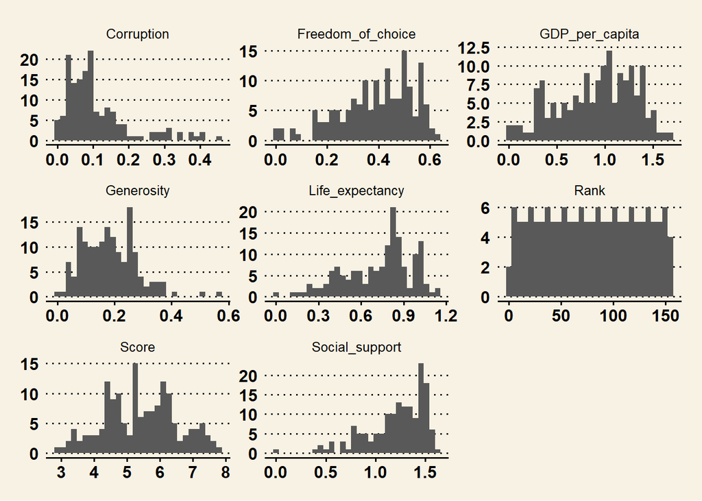

## Scatterplots

The scatterplots below shows the association between the Happines Score and each explanatory variable with a lowess curve.

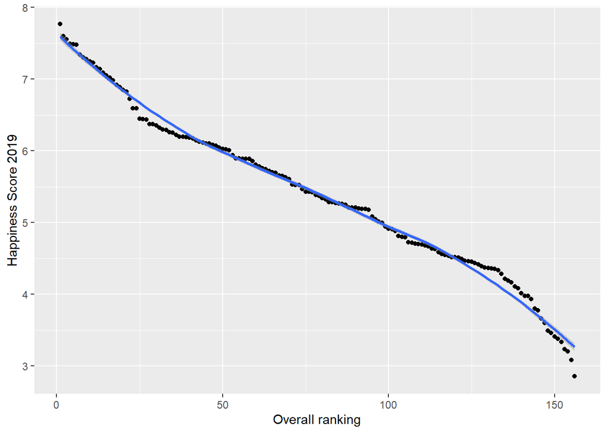

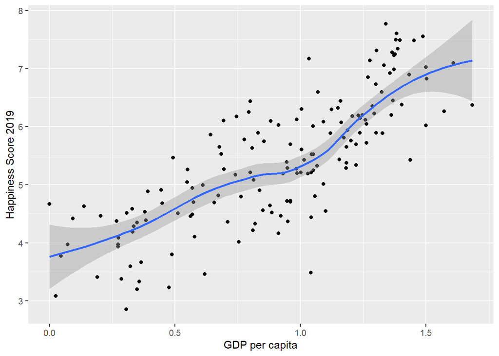

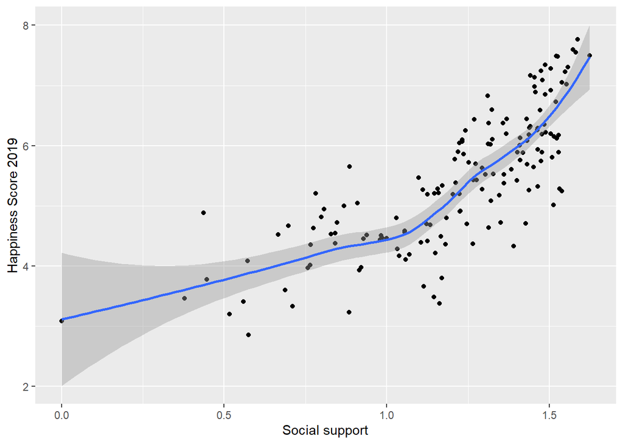

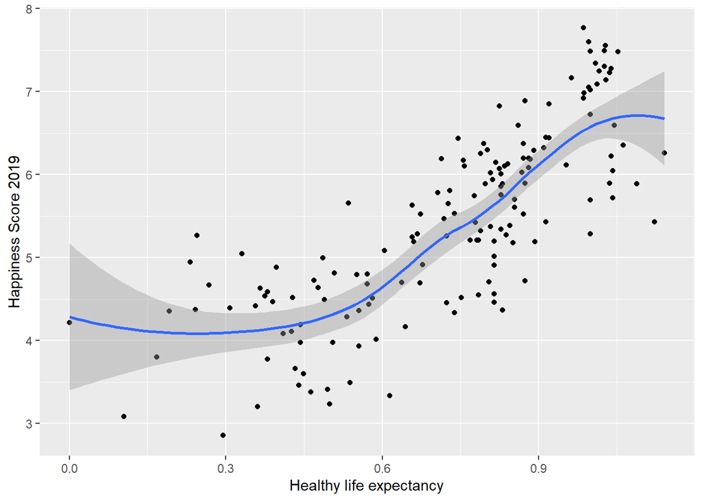

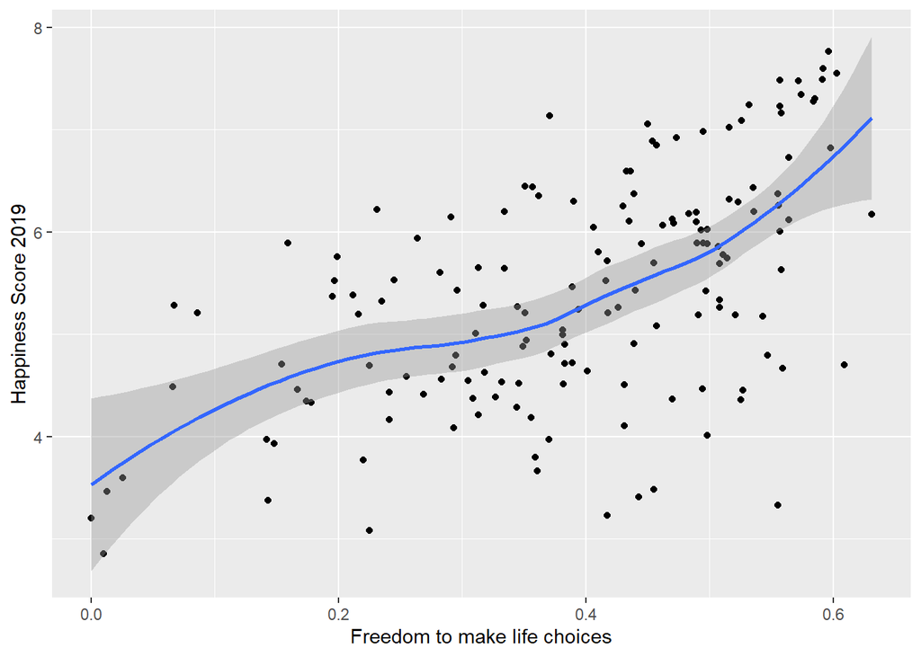

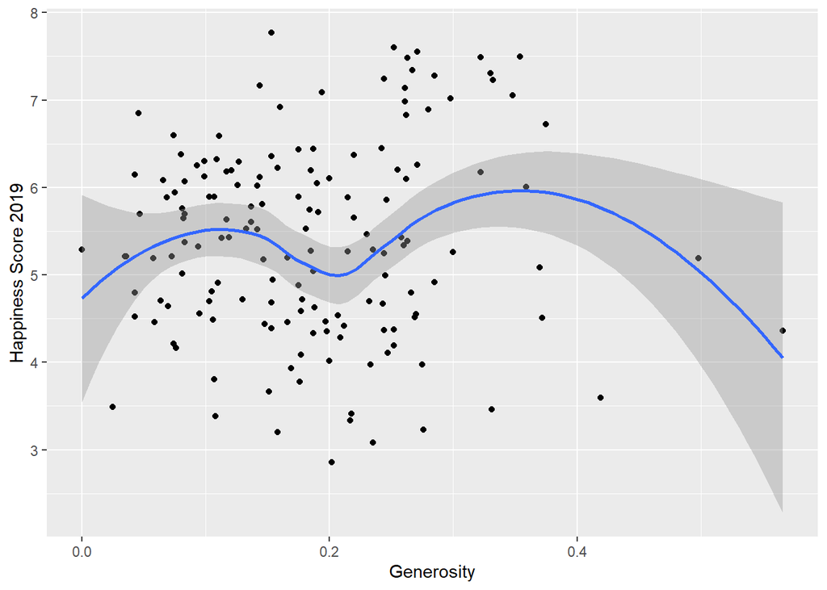

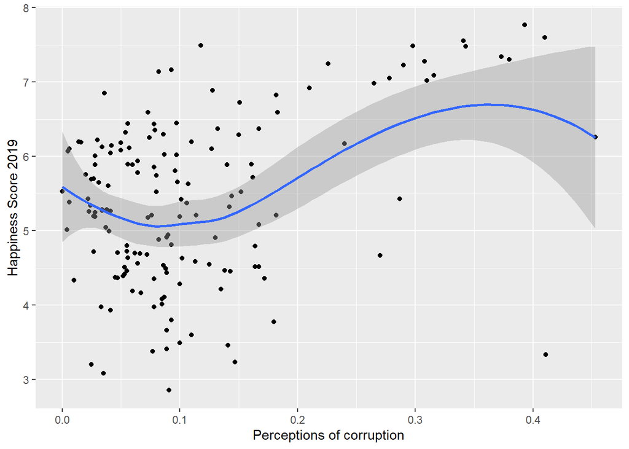

## Regression tables

The regression table shows the result of the simple linear regression for Happiness Score on GDP per capita.

Result of the simple linear regression on Happiness Score by GDP per capita

| term | estimate | std.error | statistic | p.value | conf.low | conf.high | df | outcome |
| --- | --- | --- | --- | --- | --- | --- | --- | --- |
| (Intercept) | 3.40 | 0.13 | 26.10 | 0 | 3.14 | 3.66 | 154 | Score |
| GDP_per_capita | 2.22 | 0.13 | 16.78 | 0 | 1.96 | 2.48 | 154 | Score |

The regression table below shows the result of the multiple linear regression model I.

Result of the multiple linear regression on Happiness Score

| term | estimate | std.error | statistic | p.value | conf.low | conf.high | df | outcome |
| --- | --- | --- | --- | --- | --- | --- | --- | --- |
| (Intercept) | 1.80 | 0.24 | 7.49 | 0.00 | 1.32 | 2.27 | 149 | Score |
| GDP_per_capita | 0.78 | 0.22 | 3.55 | 0.00 | 0.34 | 1.21 | 149 | Score |
| Social_support | 1.12 | 0.25 | 4.44 | 0.00 | 0.62 | 1.62 | 149 | Score |
| Life_expectancy | 1.08 | 0.35 | 3.07 | 0.00 | 0.39 | 1.77 | 149 | Score |
| Freedom_of_choice | 1.45 | 0.34 | 4.26 | 0.00 | 0.78 | 2.13 | 149 | Score |
| Generosity | 0.49 | 0.59 | 0.83 | 0.41 | -0.68 | 1.66 | 149 | Score |
| Corruption | 0.97 | 0.69 | 1.41 | 0.16 | -0.39 | 2.34 | 149 | Score |

The regression table below shows the result of the multiple linear regression model II.

Result of the multiple linear regression on Happiness Score

| term | estimate | std.error | statistic | p.value | conf.low | conf.high | df | outcome |
| --- | --- | --- | --- | --- | --- | --- | --- | --- |
| (Intercept) | 1.89 | 0.21 | 8.86 | 0 | 1.47 | 2.31 | 151 | Score |
| GDP_per_capita | 0.81 | 0.21 | 3.87 | 0 | 0.40 | 1.22 | 151 | Score |
| Social_support | 1.02 | 0.25 | 4.07 | 0 | 0.52 | 1.51 | 151 | Score |
| Life_expectancy | 1.14 | 0.36 | 3.21 | 0 | 0.44 | 1.84 | 151 | Score |
| Freedom_of_choice | 1.85 | 0.33 | 5.67 | 0 | 1.20 | 2.49 | 151 | Score |

The scatterplot below shows the true values and the estimated values by the model II.

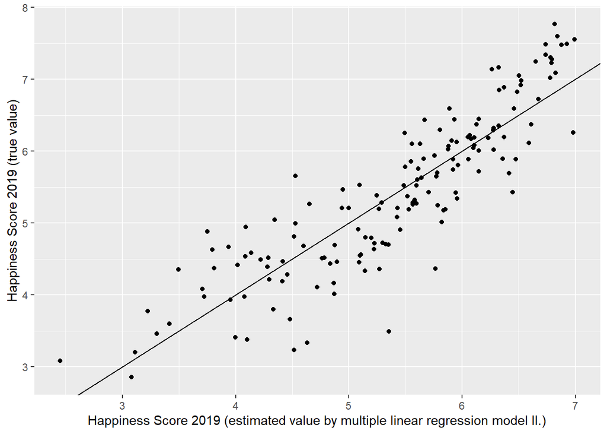